# Vantagens do Python

# Strings

## Strings

```python
print("String com uma aspa (') no meio.")
print('String com uma aspa (") no meio.')
```

```
String com uma aspa (') no meio.
String com uma aspa (") no meio.
```

```python
print('String com uma aspa (') no meio.')
```

```
  File "/tmp/ipykernel_575339/3596861209.py", line 1
    print('String com uma aspa (') no meio.')
                                   ^
SyntaxError: invalid syntax
```

```python
print('String com uma aspa (\') no meio.')
```

```
String com uma aspa (') no meio.
```

```python
# Usando "\" para ignorar a quebra da linha
print("a\
  b\
  c")
```

```
a  b  c
```

## Strings

```python
# Usando "\\" para mostrar \ (backslash)
print("comando \\LaTeX \n Use \\n para quebrar a linha")
```

```
comando \LaTeX
 Use \n para quebrar a linha
```

```python
# Use r ou R para desconsiderar a quebra de linha
print(R"Comando\n\\LaTeX")
```

```
Comando\n\\LaTeX
```

```python
print('''Nossa string tem uma aspa simples (') e uma aspa dupla (\").''')
```

```
Nossa string tem uma aspa simples (') e uma aspa dupla (").
```

```python
# Use três aspas duplas para multiplas linhas
print("""A string
que estamos escrevendo
apresenta várias linhas""")
```

```
A string
que estamos escrevendo
apresenta várias linhas
```

## Strings

```python
cor_da_caneta = "azul "
cor_da_caneta * 3 # Podemos fazer operações com strings
```

```
'azul azul azul '
```

```python
nome = 'caneta '
(nome + cor_da_caneta * 2 + nome)*2
```

```
'caneta azul azul caneta caneta azul azul caneta '
```

```python
len('(nome + cor_da_caneta * 2 + nome)*2') # Permite saber o tamanho de uma string
```

```
35
```

```python
print("e" in nome)          # Verifica se E está presente em nome e retorna True
print("e" not in nome)      # Verifica se E não está presente em nome e retorna True
```

```
True
False
```

## Strings

```python
frase = "markdown"
frase[0] # Mostra o primeiro caracter da string
```

```
'm'
```

[figure not shown]

## Strings

```python
print(frase[len(frase)-1]) # Mostra o último elemento do string
print(frase[0:5])          # Mostra os elementos do zero até o antes do 5
print(frase[:6])    # se omitido o primeiro indice, significa 'obter desde o começo'
print(frase[6:])    # Se omitido o segundo índice significa 'obter até o final'
print(frase[2:-3]) # Mostra a partir do segundo elemento até 3 elementos antes do último
```

```
n
markd
markdo
wn
rkd
```

```python
# Podemos mostrar a string fatiada usando [começo : fim : passo]
print(frase[::2]) # do começo, até o fim, de 2 em 2.
```

```
mrdw
```

```python
# Passos positivos significam para frente e passos negativos significam para trás
print(frase[2:-2:2]) # Do terceiro, até o ante penúltimo, de 2 em 2
```

```
rd
```

```python
# Quando usamos passos negativos, a fatia começa no fim e termina no começo e é percorrida ao contrário.
# Ou seja, invertemos a ordem
print(frase[::-1])
```

```
nwodkram
```

## Strings

```python
val_str = "qualquer texto"

print("Concatendo strings", val_str)
print("Concatendo strings %s" %val_str)
print("Concatendo strings " + val_str)
```

```
Concatendo strings qualquer texto
Concatendo strings qualquer texto
Concatendo strings qualquer texto
```

```python
nome = "João"
curso = "Estatística"
print("%s estuda %s na UFES" %(nome,curso))
print("O curso que {0} estuda é {1}".format(nome,curso))
```

```
João estuda Estatística na UFES
O curso que João estuda é Estatística
```

```python
import math
print("{:05.2f}".format(math.pi))
sentenca = '1 GB é igual a {:,} bytes'.format(10**9)
print(sentenca)
```

```
03.14
1 GB é igual a 1,000,000,000 bytes
```

## Strings

```python
# Imprimindo a tabela de ASCII
for c in range(123):
    print(str(c) + " - " + chr(c))
```

```
0 -
1 -
2 -
3 -
4 -
5 -
6 -
7 -
8 -
9 -
10 -

11 -
12 -
13 -
```

[output cut: 109 more lines]

## Strings

```python
# Iterando strings
s = 'Iterando Strings'
for c in s:
    print(c)
```

```
I
t
e
r
a
n
d
o

S
t
r
i
n
g
s
```

## Strings

```python
''' Podemos utilizar métodos (funções especiais) para manipular strings.'''
#
texto = " muDa A priMeira leTra "

print(texto.capitalize())              # Retorna a string com a primeira letra em maiúscula
print(texto.strip())                   # Remove todos os espaços no começo e no fim da string
print(texto.lower())                   # Retorna a string em minúsculas
print(texto.upper())                   # Retorna a string em maiúsculas
print(texto.replace("muDa", "Altera")) # O método replace substitui a string com outra string
print(texto.split(" "))                # O método split separa a string em substrings caso haja um separador,
                                       # nesse caso utilizamos o espaço (" ") e ele nos retorna uma lista de strings
```

```
 muda a primeira letra
muDa A priMeira leTra
 muda a primeira letra
 MUDA A PRIMEIRA LETRA
 Altera A priMeira leTra
['', 'muDa', 'A', 'priMeira', 'leTra', '']
```

Mais detalhes em https://docs.python.org/2/library/stdtypes.html#string-methods.

# Estrutura condicional - if, elif e else

## Estrutura condicional - if, elif e else

Com `if` podemos indicar o bloco de instruções que deve ser executado com a avaliação de uma determinada expressão, da seguinte forma:

```
if(<<expr1>>):
    <<Bloco de intruções 1>>
elif(<<expr1>>):
    <<Bloco de intruções 2>>
else:
    <<Bloco de intruções 3>>
```

> No Python, a indentação possui função bastante especial, até porque, os blocos de instrução são delimitados pela profundidade da indentação.

## Estrutura condicional - if, elif e else

```python
valor_entrada = int(input("Escreva um número: "))
if valor_entrada == 1:
    print("a entrada era 1")
elif valor_entrada == 2:
    print("a entrada era 2")
elif valor_entrada == 3:
    print("a entrada era 3")
elif valor_entrada == 4:
    print("a entrada era 4")
else:
    print("o valor de entrada não era esperado em nenhum if")
```

```
Escreva um número: 5
o valor de entrada não era esperado em nenhum if
```

# Estruturas de repetição

# Estrutura `while`

O laço de repetição `while` repete um bloco de instrução enquanto a condição definida em seu cabeçalho for verdadeiro.

```python
# Mostra os números de 1 a 10
x = 1
while(x<11):
    print("{0}".format(x))
    x+=1
```

```
1
2
3
4
5
6
7
8
9
10
```

- O `while` pode-se pensar como sendo um `if`, mas que ao invés de executar o bloco de instruções uma única vez, o mesmo executará enquanto a expressão definida seja **verdadeira**.

# Estrutura `while`

- O **Python** define a instrução `else` como uma estrutura dependente da instrução `while` cujo funcionamento é análogo ao estudado na instrução `if`.

```python
# Cenário 1: Mostra os números de 0 a 4 e a palavra 'stop'
i = 0
while i < 5:
    print(i)
    i += 1
else:
    print('stop')
```

```
0
1
2
3
4
stop
```

# Estrutura `while`

```python
# Cenário 2: Mostra os números de 0 a 3
i = 0
while i < 5:
    print(i)
    if i == 3:
        break # A instrução break finaliza abruptamente a execução das estruturas de repetição.
    i += 1
else:
    print('stop')
```

```
0
1
2
3
```

# `break` e `continue`

As instruções `break` e `continue` são ferramentas das estruturas de repetição para a interrupção do laço de repetição ou de um único ciclo.

- A instrução `break` interrompe não somente o ciclo em execução, mas também, todo o laço.
- A instrução `continue` finaliza um único laço, fazendo com que o programa execute a partir do cabeçalho da estrutura de repetição.

# `break` e `continue`

```python
print("inicio")
i = 0
n=20
while(i<n):
    i += 1
    if(i%2==0):
        continue
    elif(i>n*0.5):
        break
    print(i)
else:
    print("else")
print("fim")
```

```
inicio
1
3
5
7
9
fim
```

# Estrutura `for..in`

- A instrução `for` se caracteriza por obrigar a definir a quantidade de vezes que será executado.
- A estrutura `for` exige, inicialmente, a definição de uma variável e, em seguida, um conjunto de itens iteráveis, i.e. itens de listas, tuplas, strings, chaves de dicionários, entre muitos outros objetos:

```
for <variável> in <objeto iterável>:
    <<bloco de intruções>>
```

```python
for c in "casa" :
    print(c.capitalize())
```

```
C
A
S
A
```

# Estrutura `for..in`

```python
# Calcula o fatorial de um número
n=10
prod = 1
print("i\t Fatorial")
for i in range(1,n+1):
    prod = prod * i
    print("{0}\t {1}".format(i, prod))
```

```
i	 Fatorial
1	 1
2	 2
3	 6
4	 24
5	 120
6	 720
7	 5040
8	 40320
9	 362880
10	 3628800
```

# Função `range()`

- A função `range()` retorna uma série numérica no intervalo definido como argumento. A série retornada é um objeto iterável tipo `range` e os elementos contidos serão gerados sob demanda;
- **Sintaxe:** `range(inicio, final, passo)`, sendo os dois últimos opcionais. Todos os argumentos devem ser inteiros. Não admite argumentos de tipo `string` ou `float`.

```python
print([i for i in range(10)])
```

```
[0, 1, 2, 3, 4, 5, 6, 7, 8, 9]
```

```python
print(type(range(10))) # `range()` não retorna não uma lista contendo os elementos propriamente ditos.
```

```
<class 'range'>
```

```python
# Convertindo tipo range a list
numeros_pares = list(range(0, 10, 2))
print("lista de números pares", numeros_pares)
```

```
lista de números pares [0, 2, 4, 6, 8]
```

# Estrutura `for..in`

- A instrução `else` pode ser utilizada com o `for` da mesma forma que estudamos com a instrução `while`.

```python
# utilizando a instrução ELSE
for x in [1,2,3,4,5]:
    print(x)
else:
    print("Loop finalizado com sucesso!")
```

```
1
2
3
4
5
Loop finalizado com sucesso!
```

# Listas

## Listas

- Listas são estruturas de dados capazes de armazenar múltiplos elementos. **Todo elemento contido numa lista é também um objeto**;
- Todos os elementos que estiverem delimitados por um par de colchetes para o **Python** serão uma lista;

```python
lista_1 = ["nome", "sobrenome", "idade", "endereço"]
lista_2 = [1, 2, 3, 4, 5]
lista_3 = [1, 2.3, "Rafael", [7, "oito", 9]]
lista_4 = list((4,5,6,7)) # Usando a função list
```

- Assim como nos objetos de tipo strings, é possı́vel acessar separamente cada item de uma lista a partir de seu ı́ndice;

```python
# Uma lista dentro de outra lista é uma lista aninhada.
lista3 = [1, 2.3, "Rafael", [7, "oito", 9]]
print(lista3[3])
```

```
[7, 'oito', 9]
```

## Listas

- Como no caso das strings, ao utilizar um ı́ndice negativo os elementos são acessados de trás pra frente;

```python
lista3[::-1]
```

[output not shown]

```python
print(lista3[5])
```

```
---------------------------------------------------------------------------
NameError                                 Traceback (most recent call last)
/tmp/ipykernel_575810/995304546.py in <module>
----> 1 print(lista3[5])

NameError: name 'lista3' is not defined
```

## Listas

- Com os operadoradores `in` e `not in` podemos avaliar se um valor existe ou não em uma lista;

```python
lista = ['frutas',['cı́tricas', ['laranja', 'limão']], [7, "oito",9]]

print("Frutas" in lista)
print("Laranja" in lista)
print("oito" in lista)
print("\n Tamanho da lista:",len(lista),"\n")
print("oito" not in lista)
print([7, "oito", 9] in lista)
print("oito" in lista[2])
print("frutas" in lista)
```

```
False
False
False

 Tamanho da lista: 3

True
True
True
True
```

## Listas

- A forma mais comum de percorrer os elementos em uma lista é com um `for`;

```python
# Podemos percorrer listas com for de duas maneiras:
vingadores = ['Homem de Ferro', 'Hulk', 'Capitão America', 'Viúva Negra', 'Gavião Arqueiro']

# ****** Alternativa 1 ******
# Funciona bem se você precisa apenas ler os elementos da lista.
for k in vingadores:
    print('Vingador:', k)
```

```python
# ****** Alternativa 2 ******
# Se o interesse está em escrever ou atualizar os elementos da lista, você precisa dos índices.
for i in range(0, len(vingadores)):
    print('Vingador:', vingadores[i])
```

## Compreensão de listas

- Compreensão de listas (*List Comprehensions*) é uma funcionalidade muito **poderosa** do **Python** que possibilita criar uma lista aplicando uma função para cada elemento da lista original;
- Com a compreensão de lista é possível reduzir a expressão em um única linha, num formato semelhante a notação de conjuntos da matemática, economizando linhas de códigos. O formato geral da compreensão é:

  `[<<Função de saída>> for <<variável>> in <<sequência>> if <<filtro>>]`

**Exemplo:**

$A=\{x: x\in\mathbb{Z}, x<20, x \text{ é par}\}$

**Python**: `A = [x for x in range(0, 20) if x % 2 == 0]`

## Compreensão de listas

```python
# Imprime as vogais do texto
texto = 'Muito divertida a aula de python'
vogais = [i for i in texto if i in 'aeiou']
print(vogais)
```

```
['u', 'i', 'o', 'i', 'e', 'i', 'a', 'a', 'a', 'u', 'a', 'e', 'o']
```

```python
for i in range(1, 100):
    if int(i**0.5) == i**0.5:
        print(i)
```

```
1
4
9
16
25
36
49
64
81
```

```python
print([ i for i in range(1, 100) if int(i**0.5) == i**0.5 ])
```

```
[1, 4, 9, 16, 25, 36, 49, 64, 81]
```

## Removendo elementos de uma lista

- `del`: deleta um elemento em um ı́ndice especı́fico;

```python
lista = [2, 1, 3, [1,"a"], 3, 7, "manga"]
del(lista[-1])
print(lista)
#del(lista) # caso não especifique um índice, elimina sua lista por completo!
```

```
[2, 1, 3, [1, 'a'], 3, 7]
```

```python
del(lista) # caso não especifique um índice, elimina sua lista por completo!
print(lista)
```

```
---------------------------------------------------------------------------
NameError                                 Traceback (most recent call last)
/tmp/ipykernel_575810/2435618407.py in <module>
      1 del(lista) # caso não especifique um índice, elimina sua lista por completo!
----> 2 print(lista)

NameError: name 'lista' is not defined
```

## Removendo elementos de uma lista

- O método `pop` remove o **último** elemento da lista e retorna o elemento removido;

```python
lista = [2, 1, 3, [1,"a"], 3, 7, "manga"]
lista.pop()
print(lista)
```

```
[2, 1, 3, [1, 'a'], 3, 7]
```

## Removendo elementos de uma lista

- O método `remove` remove um elemento especı́fico da lista;

```python
lista = [2, 1, 3, [1,"a"], 3, 7, "manga"]
lista.remove(2)
print(lista)

# Se o elemento ocorre múltiplas vezes, remove a primeira ocorrência
lista.remove(3)
print(lista)
```

```
[1, 3, [1, 'a'], 3, 7, 'manga']
[1, [1, 'a'], 3, 7, 'manga']
```

- Caso o elemento não estiver presente na lista, mostrará um erro `ValueError`;

```python
lista.remove(4)
```

```
---------------------------------------------------------------------------
ValueError                                Traceback (most recent call last)
/tmp/ipykernel_575810/2138286988.py in <module>
----> 1 lista.remove(4)

ValueError: list.remove(x): x not in list
```

## Outros métodos para listas

- **clear**: Remove todos os itens da lista;
- **extend**: Adiciona um elemento de uma lista para outra lista;
- **append**: Adiciona um único elemento para a lista;
- **insert**: Insere um elemento na lista;
- **copy**: Retorna uma cópia da lista;
- **sort**: Organiza os elementos da lista em ordem ascendente;
- **reverse**: Inverte a lista;
- **index**: Retorna o ı́ndice de um elemento na lista.
- **count**: Retorna ocorrências de um elemento na lista;

## Outros métodos para listas

```python
# Exemplos
lista1 = [2, 1, 3, 5,['a','b']]
lista2, lista3 = [[4, 3, 9],6, "texto"], [1,2,3]

# extend
lista1.extend(lista2+lista3)
print(lista1)
```

```
[2, 1, 3, 5, ['a', 'b'], [4, 3, 9], 6, 'texto', 1, 2, 3]
```

```python
# count
print(lista1.count(3)) # Contando ocorrências do número 3
```

```
2
```

```python
# clear
lista1.clear() # Deleteando os elementos da lista1
print(lista1)
```

```
[]
```

## Outros métodos para listas

```python
municipios = ['Serra', 'Vila Velha', 'Cariacica']
municipios.append('Vitória') # append adiciona um elemento ao final da lista municipios

print(municipios)

# append não permite mais de um argumento.
municipios.append('Castelo','Iconha', 'Guarapari','Viana')
```

```
['Serra', 'Vila Velha', 'Cariacica', 'Vitória']
```

```
---------------------------------------------------------------------------
TypeError                                 Traceback (most recent call last)
/tmp/ipykernel_575810/1716735380.py in <module>
      5
      6 # append não permite mais de um argumento.
----> 7 municipios.append('Castelo','Iconha', 'Guarapari','Viana')

TypeError: append() takes exactly one argument (4 given)
```

## Outros métodos para listas

```python
 # Nesse caso utilize o método extend
municipios.extend(['Castelo','Iconha', 'Guarapari','Viana'])
print(municipios)
```

```
['Serra', 'Vila Velha', 'Cariacica', 'Vitória', 'Castelo', 'Iconha', 'Guarapari', 'Viana']
```

```python
# insert permite inserir um elemento na posição especificada
municipios.insert(3, 'Alegre')
print(municipios)
```

```
['Serra', 'Vila Velha', 'Cariacica', 'Alegre', 'Vitória', 'Castelo', 'Iconha', 'Guarapari', 'Viana']
```

## Outros métodos para listas

```python
# Método sort, reverse e index
municipios = ['Serra', 'Vila Velha', 'Cariacica', 'Alegre', 'Vitória','Castelo', 'Iconha', 'Guarapari', 'Viana']
municipios.sort()
print(municipios)

municipios.reverse()
print("\n", municipios)

print("\nO ı́ndice do municipio 'Castelo' é {}".format(municipios.index("Castelo")))
```

```
['Alegre', 'Cariacica', 'Castelo', 'Guarapari', 'Iconha', 'Serra', 'Viana', 'Vila Velha', 'Vitória']

 ['Vitória', 'Vila Velha', 'Viana', 'Serra', 'Iconha', 'Guarapari', 'Castelo', 'Cariacica', 'Alegre']

O ı́ndice do municipio 'Castelo' é 6
```

```python
# Utilize o método copy para copiar listas
estado=municipios.copy()
estado.append('Muqui')
print("municipios= {} ".format(municipios))
print("estado= {} ".format(estado))
```

```
municipios= ['Vitória', 'Vila Velha', 'Viana', 'Serra', 'Iconha', 'Guarapari', 'Castelo', 'Cariacica', 'Alegre']
estado= ['Vitória', 'Vila Velha', 'Viana', 'Serra', 'Iconha', 'Guarapari', 'Castelo', 'Cariacica', 'Alegre', 'Muqui']
```

# Funções embutidas (built-in) para listas

O interpretador do Python possui várias funções e tipos embutidos que sempre estão disponíveis. A seguir listamos algumas dessas funções:

- **all**: Verifica se todos os elementos contidos na lista são verdadeiros ou se a lista for vazia;
- **any**: Retorna verdadeiro se algum dos elementos da lista for verdadeiro. Se a lista for vazia ela retorna falso;
- **enumerate**: Retorna uma tupla de dois elementos a cada iteração: um número sequencial e um item da sequência correspondente;
- **filter**: filtra os elementos de uma sequência. O processo de filtragem é definido a partir de uma função que o programador passa como primeiro argumento da função;
- **len**: Devolve o comprimento (o número de itens) de um objeto;

# Funções embutidas (built-in) para listas

- **map**: Aplica uma função a cada elemento de uma lista, retornando uma nova lista contendo os elementos resultantes da aplicação da função;
- **max**: Retorna o maior elemento;
- **min**: Retorna o menor elemento;
- **pow**: Retorna a potência de um número;
- **sum**: Soma todos os elementos de uma lista;
- **zip**: retorna uma lista de tuplas, onde a i-ésima tupla contém o i-ésimo elemento de cada um dos argumentos.

# Funções embutidas (built-in) para listas

```python
ip.IFrame('https://docs.python.org/pt-br/3/library/functions.html', width='100%', height=650)
```

[interactive chart not shown]

# Funções embutidas (built-in) para listas

```python
numeros = [i for i in range(10)] # Compreensão de lista

print("numeros=",numeros,"\nSoma=",sum(numeros),"Min=",min(numeros),"Máx=",max(numeros))
```

```
numeros= [0, 1, 2, 3, 4, 5, 6, 7, 8, 9]
Soma= 45 Min= 0 Máx= 9
```

```python
seasons = ['Spring', 'Summer', 'Fall', 'Winter']

print(list(enumerate(seasons,start=1)))
```

```
[(1, 'Spring'), (2, 'Summer'), (3, 'Fall'), (4, 'Winter')]
```

```python
# Função para identificar as vogais
def vogal(letra):
    vogais = ['a', 'e', 'i', 'o', 'u']
    if letra in vogais:
        return True
    else:
        return False

letras = ['u', 'a', 'q', 'c', 'i', 'd', 'z', 'p', 'e']
filtro = filter(vogal, letras)
print(list(filtro))
```

```
['u', 'a', 'i', 'e']
```

# Funções embutidas (built-in) para listas

```python
for item in zip([1, 2, 3], ['sugar', 'spice', 'everything nice']):
    print(item)
```

```
(1, 'sugar')
(2, 'spice')
(3, 'everything nice')
```

```python
list(zip(range(3), ['fee', 'fi', 'fo', 'fum']))
```

```
[(0, 'fee'), (1, 'fi'), (2, 'fo')]
```

```python
list(zip(range(3), ['fee', 'fi', 'fo', 'fum'],strict=True))
```

```
---------------------------------------------------------------------------
TypeError                                 Traceback (most recent call last)
/tmp/ipykernel_575810/3525701347.py in <module>
----> 1 list(zip(range(3), ['fee', 'fi', 'fo', 'fum'],strict=True))

TypeError: zip() takes no keyword arguments
```

# Exemplos

```python
from random import randint
import statistics

a, b, n = 1, 7, 10
numeros = list((randint(a,b) for i in range(n))) # Criando a lista de números pseudo-aleatórios
numeros.sort() # Ordenando a lista

print("lista de números gerados aleatoriamente (ordenados)= {}".format(numeros))
print("Mı́nimo = {0} e Máximo = {1}".format(min(numeros),max(numeros)))
print("Média aritmética= %2.2f" %(sum(numeros)/n)+"\tMediana= %2.2f" %statistics.median(numeros))

contagem = list(enumerate([numeros.count(i) for i in range(a,b+1)]))
max_freq= max([contagem[i][1] for i in range(b-a+1)])
print("Valor(es) com maior ocorrência (moda): ", end= " ")

for i in range(b-a+1):
    if(contagem[i][1]==max_freq):
        print(contagem[i][0]+a, end=" ")
```

```
lista de números gerados aleatoriamente (ordenados)= [1, 1, 2, 3, 4, 4, 5, 6, 7, 7]
Mı́nimo = 1 e Máximo = 7
Média aritmética= 4.00	Mediana= 4.00
Valor(es) com maior ocorrência (moda):  1 4 7
```

```python
import math
import random
a, b, n = 1, 7, 10
numeros = list((randint(a,b) for i in range(n)))
numeros.extend([None]*6); random.shuffle(numeros)
print("Sequência com valores 'None': ", numeros)

res1 = list(filter(None, numeros))
print("Sequência sem 'None': ",res1)

pares = [i for i in res1 if i%2 == 0]
print("Números pares: ",pares)

maiores_dois = filter(lambda x: x > 2, res1)
print("Maiores que 2: {}".format(list(maiores_dois)))

raiz_quad = list(map(math.sqrt, res1))
print("Raiz quadrada= {}".format([round(x,2) for x in raiz_quad]))
print("Quadrado= {}".format([round(math.pow(x,2)) for x in raiz_quad]))
```

```
Sequência com valores 'None':  [5, 6, 2, None, None, 5, 2, 4, 4, None, None, 7, None, None, 7, 1]
Sequência sem 'None':  [5, 6, 2, 5, 2, 4, 4, 7, 7, 1]
Números pares:  [6, 2, 2, 4, 4]
Maiores que 2: [5, 6, 5, 4, 4, 7, 7]
Raiz quadrada= [2.24, 2.45, 1.41, 2.24, 1.41, 2.0, 2.0, 2.65, 2.65, 1.0]
Quadrado= [5, 6, 2, 5, 2, 4, 4, 7, 7, 1]
```

```python
from random import randint

a, b, n, valor = 10, 70, 20, b
numeros = list((randint(a,b) for i in range(n)))
print("Sequência de valores: ", numeros)

def Teste_Numero_Menor(lista, valor):
    return(all(i < valor for i in lista))

if (Teste_Numero_Menor(numeros, valor)):
    print("Sim, todos o valores são menores que {0}. Valor máximo é {1}.".format(valor,max(numeros)))
else:
    print("Não, existe pelo menos um valor {} na sequência.".format(valor))
```

```
Sequência de valores:  [13, 45, 15, 40, 50, 57, 18, 52, 47, 16, 53, 57, 61, 58, 25, 19, 32, 57, 44, 45]
Não, existe pelo menos um valor 7 na sequência.
```

```python
from random import randint
n,b=10,9
lista = list((randint(0,b) for i in range(n)))
contagem = [0]*n

print("lista de números aleatórios entre 0 e {0} = {1}".format(n,lista))
contagem = list(enumerate([lista.count(i) for i in range(n)]))
print("\nValor\tfrequência")
for i in range(b+1):
    print(contagem[i][0],"\t",contagem[i][1])
```

```
lista de números aleatórios entre 0 e 10 = [6, 8, 5, 7, 1, 2, 2, 7, 3, 2]

Valor	frequência
0 	 0
1 	 1
2 	 3
3 	 1
4 	 0
5 	 1
6 	 1
7 	 2
8 	 1
9 	 0
```

# Tuplas

# Dicionários

# Funções

```python
quadrados = []
for i in range(10):
    quadrados.append(i * i)

print(quadrados)
```

```
[0, 1, 4, 9, 16, 25, 36, 49, 64, 81]
```

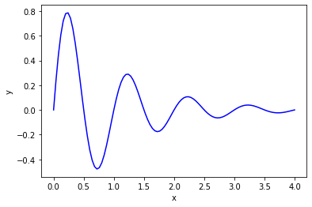

```python
import numpy as np
import math
import matplotlib.pyplot as plt
%matplotlib inline
x = np.linspace(0, 4, 101)
y = np.exp(-x)*np.sin(2*math.pi*x)
plt.plot(x, y, 'b-')
plt.xlabel('x'); plt.ylabel('y')
```

```python
import random
import numpy as np
import pandas as pd
import seaborn as sns
import matplotlib.pyplot as plt
import scipy as sp


random.seed(2427);

# help(random)
```

```python
print(random.random(),random.uniform(0,1))
```

```
0.6709313964859867 0.9738115340563225
```

```python
def amostra(n):
    x = [random.uniform(0,1) for j in range(n)]
    return x

amostra(20)
```

```
[0.6709313964859867,
 0.9738115340563225,
 0.6064264401595373,
 0.4066259803173813,
 0.241007454546324,
 0.9570332484250537,
 0.2349020347673353,
 0.8876755137054037,
 0.9720131163571095,
 0.1492980772443857,
 0.9414046155591562,
 0.5597323750561738,
 0.7608989127589141,
 0.5249642801198838,
 0.1344891272249087,
 0.9796560039964438,
 0.06863221669260322,
 0.8766064411366202,
 0.5504489926930571,
 0.4880661379761838]
```

```python
n, p = 1, 0.5  # numero de eventos, probabilidade de sucesso

N =100 # Tamanho de amostra
amostra = np.random.binomial(n, p, N); #print(amostra)

numero_sucesso=sum(amostra);print(numero_sucesso)
numero_fracasso=N-numero_sucesso; print(numero_fracasso)
```

```
48
52
```

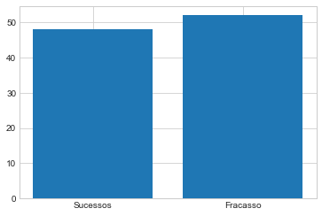

```python
plt.style.use("seaborn-whitegrid")

#print(plt.style.available)

height = [numero_sucesso, numero_fracasso]
bars = ('Sucessos', 'Fracasso')
y_pos = np.arange(len(bars))

plt.bar(y_pos, height)

# Coloca os nomes no eixo x
plt.xticks(y_pos, bars)

# Mostra o gráfico

plt.show()
```

```python
dados = np.round(np.random.randn(100,7), 2) # Dados artificiais
df = pd.DataFrame(dados, columns=['Time','PosX', 'PosY', 'PosZ', 'VelX', 'VelY', 'VelZ']) # Nomes das variáveis
print(df)
```

```
    Time  PosX  PosY  PosZ  VelX  VelY  VelZ
0  -0.55 -0.26 -1.41 -1.22 -1.66 -1.91 -1.49
1  -0.48  0.03 -0.21 -0.71  2.31  0.56  0.12
2  -0.35 -0.20 -0.33 -0.45 -1.33 -0.43 -0.38
3   0.41 -0.28  0.44  1.25 -0.83  2.39 -0.99
4  -1.25 -0.82  0.11 -0.58  0.68  0.05  0.61
..   ...   ...   ...   ...   ...   ...   ...
95  1.31  1.79  0.98  0.43  0.47 -1.00  0.85
96  0.34 -0.57  1.09 -1.13 -1.27 -0.48 -0.23
97  0.01  0.06 -0.08  0.22  0.59  0.87  1.11
98  0.74 -0.14  0.53  0.28 -0.42 -2.49 -0.35
99 -1.19 -0.72 -0.93 -0.07 -0.81 -1.59 -0.08

[100 rows x 7 columns]
```

```python
vel = df.filter(regex='Vel*') # Filtra os dados de velocidade
print(vel)
```

```
    VelX  VelY  VelZ
0  -1.66 -1.91 -1.49
1   2.31  0.56  0.12
2  -1.33 -0.43 -0.38
3  -0.83  2.39 -0.99
4   0.68  0.05  0.61
..   ...   ...   ...
95  0.47 -1.00  0.85
96 -1.27 -0.48 -0.23
97  0.59  0.87  1.11
98 -0.42 -2.49 -0.35
99 -0.81 -1.59 -0.08

[100 rows x 3 columns]
```

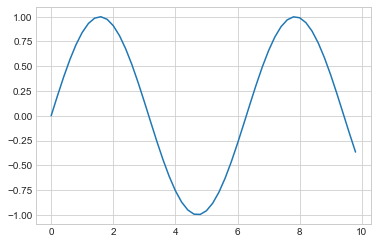

```python
x = np.arange(0, 10, 0.2)
y = np.sin(x)

# Generate the plot
plt.plot(x, y)
plt.show()
```

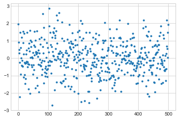

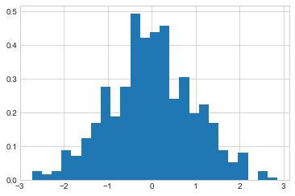

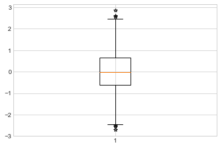

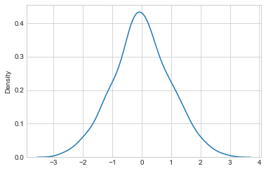

```python
x = np.random.randn(500)

plt.plot(x, '.')
plt.show()

plt.hist(x, bins=25,density=True)
plt.show()

plt.boxplot(x, sym='*')
plt.show()

sns.kdeplot(x)
```

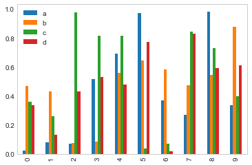

```python
df = pd.DataFrame(np.random.rand(10, 4),
columns=['a', 'b', 'c', 'd'])
df.plot(kind='bar', grid=False)
```

[output not shown]

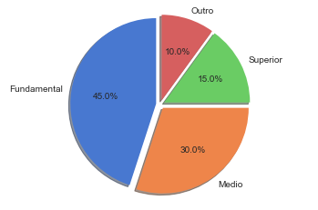

```python
txtLabels = 'Fundamental', 'Medio', 'Superior', 'Outro'
fractions = [45, 30, 15, 10]
offsets =(0.05, 0.05, 0.05, 0.05)
plt.pie(fractions, explode=offsets, labels=txtLabels,
autopct='%1.1f%%', shadow=True, startangle=90,
colors=sns.color_palette('muted') )
plt.axis('equal')
```

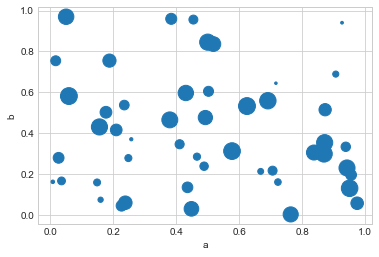

```python
df2 = pd.DataFrame(np.random.rand(50, 4),columns=['a', 'b', 'c', 'd'])
df2.plot(kind='scatter', x='a', y='b', s=df2['c']*300)
```

```python
x = pd.DataFrame(np.random.randn(500),columns=['x'])
x.describe()
```

|  | x |
| --- | --- |
| count | 500.000000 |
| mean | 0.022964 |
| std | 0.979212 |
| min | -2.834124 |
| 25% | -0.659795 |
| 50% | 0.026259 |
| 75% | 0.743096 |
| max | 2.624101 |

```python
print(x.mean())
```

```
x    0.022964
dtype: float64
```

```python
print(np.mean(x))
```

```
x    0.022964
dtype: float64
```

```python
print(sp.stats.mode(x))
```

```
ModeResult(mode=array([[-2.834124]]), count=array([[1]]))
```

```python
from scipy import stats
print(stats.mode(x))
```

```
ModeResult(mode=array([[-2.834124]]), count=array([[1]]))
```

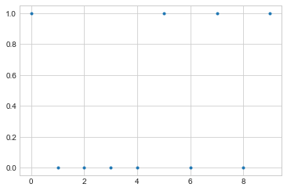

```python
p = 0.5
bernoulli = stats.bernoulli(p)

plt.plot(bernoulli.rvs(10), '.')
plt.show()
```

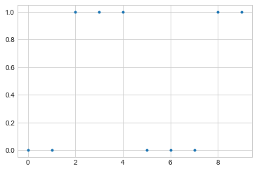

```python
(p, n) = (0.5, 1)
binomial = stats.binom(n, p)
plt.plot(binomial.rvs(10), '.')
plt.show()
```

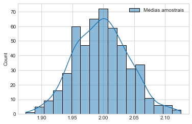

```python
n=500
rep = 500

df = pd.DataFrame()

for i in range(1, rep+1):
    amostra = np.random.binomial(4,0.5, n)
    col = f'amostra {i}'
    df[col] = amostra

df.describe()

# Plotting the sampling distribution from a
df_medias = pd.DataFrame(df.mean(),columns=['Médias amostrais'])
sns.histplot(df_medias,kde=True);
```

```python
from scipy.stats import randint

(a,b)=(1,5)

x = pd.DataFrame(randint.rvs(a, b, size=100),columns=['x'])

x.head(20)
```

|  | x |
| --- | --- |
| 0 | 3 |
| 1 | 2 |
| 2 | 1 |
| 3 | 1 |
| 4 | 2 |
| 5 | 3 |
| 6 | 4 |
| 7 | 2 |
| 8 | 2 |
| 9 | 4 |
| 10 | 2 |
| 11 | 3 |
| 12 | 1 |
| 13 | 2 |
| 14 | 1 |
| 15 | 1 |
| 16 | 1 |
| 17 | 1 |
| 18 | 4 |
| 19 | 4 |

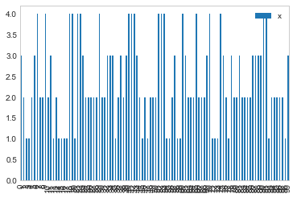

```python
x.plot(kind='bar', grid=False)
```

```python
import matplotlib
matplotlib.__version__
```

```
'3.4.2'
```

```python
!python3 --version
```

```
Python 3.8.10
```